# Лабораторийн ажил 15-16

## Cluster Analysis

Кластерын шинжилгээ нь оролтын өгөгдлийг хоорондоо нягт холбоотой тохиолдлуудын бүлгүүдэд хуваахыг эрмэлздэг бөгөөд ингэснээр нэг кластерт хамаарах тохиолдлууд нь бусад кластерт хамаарах тохиолдлуудаас илүү төстэй байх болно.

## 15.1 K-means Clustering

k-means алгоритм нь кластер бүрийг түүний харгалзах кластерын төвөөр (centroid) илэрхийлдэг. Алгоритм нь дараах хоёр алхмыг давталттайгаар хэрэгжүүлэх замаар оролтын өгөгдлийг *k* салангид кластерт хуваах болно.

1. Цэг бүрийг хамгийн ойрын центройд руу оноож *k* кластер үүсгэх.
2. Кластер бүрийн центройдыг дахин тооцоолох.

Энэ хэсэгт бид киноны үнэлгээний өгөгдлийн багцын жишээн дээр k-means кластер хийж гүйцэтгэнэ. Эхлээд өгөгдлийн багцыг дараах байдлаар үүсгэе.

```python
import pandas as pd

ratings = [['john',5,5,2,1],['mary',4,5,3,2],['bob',4,4,4,3],['lisa',2,2,4,5],['lee',1,2,3,4],['harry',2,1,5,5]]
titles = ['user','Jaws','Star Wars','Exorcist','Omen']
movies = pd.DataFrame(ratings,columns=titles)
movies
```

Жишээ өгөгдлийн багцад эхний 3 хэрэглэгч тулаант кинонд (Jaws болон Star Wars) дуртай байсан бол сүүлийн 3 хэрэглэгчид аймшгийн кино (Exorcist болон Omen) таалагдсан байна. Бидний зорилго бол ижил төстэй киноны сонголттой хэрэглэгчдийн бүлгийг тодорхойлохын тулд хэрэглэгчдэд k-means кластерийг ашиглах явдал юм.

Доорх жишээ нь киноны үнэлгээний өгөгдөлд k-means кластерийг (k=2) хэрхэн ашиглахыг харуулна. Кластер хийх алгоритмыг хэрэглэхийн өмнө эхлээд **"user"** баганыг арилгах ёстой. Хэрэглэгч бүрийн кластерын хуваарилалтыг dataframe объект хэлбэрээр харуулъя. Кластерийн анхны төвийг тодорхойлоход **'k-means++'** болон **'random'** сонголтууд байх ба бид энэ тохиолдолд **'k-means++'** аргыг ашигласан.

```python
from sklearn import cluster

data = movies.drop('user',axis=1)
X = data.to_numpy()

k_means = cluster.KMeans(n_clusters=2, init = 'k-means++', max_iter=50, random_state=42)
k_means.fit(X)
labels = k_means.labels_
pd.DataFrame(labels, index=movies.user, columns=['Cluster ID'])
```

```python
centroids = k_means.cluster_centers_
pd.DataFrame(centroids,columns=data.columns)
```

```python
import numpy as np

testData = np.array([[4,5,1,2],[3,2,4,4],[2,3,4,1],[3,2,3,3],[5,4,1,4]])
labels = k_means.predict(testData)
labels = labels.reshape(-1,1)
usernames = np.array(['paul','kim','liz','tom','bill']).reshape(-1,1)
cols = movies.columns.tolist()
cols.append('Cluster ID')
newusers = pd.DataFrame(np.concatenate((usernames, testData, labels), axis=1),columns=cols)
newusers
```

Өгөгдөл дэх кластеруудын оновчтой тоог тодорхойлохын тулд k-means алгоритмыг 1-ээс 6 хүртэлх кластерын янз бүрийн тоотой хэрэглэж, тэдгээрийн харгалзах алдааны квадратуудын нийлбэрийг (SSE-sum of squared errors) доорх жишээнд үзүүлсэн шиг тооцоолж болно. Кластерын тоог үнэлэхийн тулд SSE-ийг кластерын тоотой харьцуулсан график дахь **"elbow"**-г ашиглаж болно. "elbow" нь гол өөрчлөлтийг олж авахад тустай байдаг ба графикийг хүний гартай зүйрлэвэл тохой буюу нугарч байгаа цэгийг "elbow" гэж үзнэ.

```python
import matplotlib.pyplot as plt
%matplotlib inline

numClusters = [1,2,3,4,5,6]
SSE = []
for k in numClusters:
    k_means = cluster.KMeans(n_clusters=k, n_init=1)
    k_means.fit(data)
    SSE.append(k_means.inertia_)  # SSE

plt.plot(numClusters, SSE)
plt.xlabel('Number of Clusters')
plt.ylabel('SSE')
plt.scatter(2,SSE[1], s = 200, c = 'red', marker='*')
```

[output not shown]

## 15.2 Hierarchical Clustering

Энэ хэсэгт өмнөх лабораторид ашиглагдаж байсан сээр нуруутан амьтдын өгөгдлийн багцад шаталсан кластерыг ашиглана. Тодруулбал, Python scipy сангаар хангагддаг шаталсан кластерийн 3 алгоритмыг ашигласан үр дүнг харуулна: (1) single link (MIN), (2) complete link (MAX), (3) group average. Уг сангаас хангадаг бусад шаталсан кластерын алгоритмууд нь центройдод суурилсан болон Ward-ийн аргыг агуулдаг.

```python
import pandas as pd

data = pd.read_csv('vertebrate.csv',header='infer')
data
```

### 15.2.1 Single Link (MIN)

```python
from scipy.cluster import hierarchy
import matplotlib.pyplot as plt
%matplotlib inline

names = data['Name']
X1 = data.drop(['Name','Class'],axis=1)
Z = hierarchy.linkage(X1, 'single')
dn = hierarchy.dendrogram(Z,labels=names.tolist(),orientation='right')
```

### 15.2.2 Complete Link (MAX)

```python
Z = hierarchy.linkage(X1, 'complete')
dn = hierarchy.dendrogram(Z,labels=names.tolist(),orientation='right')
```

### 15.2.3 Group Average

```python
Z = hierarchy.linkage(X1, 'average')
dn = hierarchy.dendrogram(Z,labels=names.tolist(),orientation='right')
```

## 15.3 Density-Based Clustering

Нягтад суурилсан кластер нь бага нягтралтай бүсээр тусгаарлагдсан өндөр нягтралтай бүсийг тодорхойлдог. DBSCAN бол хамгийн алдартай нягтад суурилсан алгоритмуудын нэг юм. DBSCAN-д өгөгдлийн цэгүүдийг 3 төрөлд ангилагдана.

1. Гол цэгүүд (core points)
2. Хилийн цэгүүд (border point)
3. Шуугианы цэгүүд (noisy point)

2 параметрийг тодорхойлно: радиус (eps) болон уг радиус дотор байх цэгийн минимум тоо (min_samples) Энэ аргад зориулан дараах шуугиантай, 2 хэмжээст өгөгдлийн багцыг ашиглана. Дараах код нь өгөгдлийг ачаалж, тархалтын графикийг харуулна.

```python
import pandas as pd

data = pd.read_csv('chameleon.data', delimiter=' ', names=['x','y'])
data.plot.scatter(x='x',y='y')
```

eps=15.5, min_samples=5 гэсэн тохируулгатайгаар DBScan кластерийн алгоримтыг өгөгдөл дээр хэрэгжүүлнэ. Кластеруудад 0-8 хооронд ID буюу дугаар оноох ба шуугианы цэгүүдийг (noise points) ID нь -1 тэнцүү кластерт хуваарилна.

```python
from sklearn.cluster import DBSCAN

db = DBSCAN(eps=15.5, min_samples=5).fit(data)
core_samples_mask = np.zeros_like(db.labels_, dtype=bool)
core_samples_mask[db.core_sample_indices_] = True
labels = pd.DataFrame(db.labels_,columns=['Cluster ID'])
result = pd.concat((data,labels), axis=1)
result
```

```python
result.plot.scatter(x='x',y='y',c='Cluster ID', colormap='jet')
```

## 15.4 Spectral Clustering

k-means кластерын алгоритмын гол хязгаарлалтуудын нэг нь бөмбөрцөг хэлбэртэй кластеруудыг эрэлхийлэх хандлага юм. Тиймээс дурын хэлбэртэй кластер бүхий өгөгдлийн багцад ашиглах эсвэл кластерын төвүүд (centroids) хоорондоо давхцах үед энэ нь ажиллахгүй. Ижил төстэй байдлын графын (similarity graph) шинж чанарыг ашиглан spectral clustering нь энэ хязгаарлалтыг даван туулж чадна. Үүнийг харуулахын тулд дараах хоёр хэмжээст өгөгдлийн багцыг авч үзье.

```python
import pandas as pd

data1 = pd.read_csv('2d_data.txt', delimiter=' ', names=['x','y'])
data2 = pd.read_csv('elliptical.txt', delimiter=' ', names=['x','y'])

fig, (ax1,ax2) = plt.subplots(nrows=1, ncols=2, figsize=(12,5))
data1.plot.scatter(x='x',y='y',ax=ax1)
data2.plot.scatter(x='x',y='y',ax=ax2)
```

Дараах жишээнд, өгөгдлийн багцад k-means (k=2) ашиглах үеийн үр дүнг харуулав.

```python
from sklearn import cluster

k_means = cluster.KMeans(n_clusters=2, max_iter=50, random_state=1)
k_means.fit(data1)
labels1 = pd.DataFrame(k_means.labels_,columns=['Cluster ID'])
result1 = pd.concat((data1,labels1), axis=1)

k_means2 = cluster.KMeans(n_clusters=2, max_iter=50, random_state=1)
k_means2.fit(data2)
labels2 = pd.DataFrame(k_means2.labels_,columns=['Cluster ID'])
result2 = pd.concat((data2,labels2), axis=1)

fig, (ax1,ax2) = plt.subplots(nrows=1, ncols=2, figsize=(12,5))
result1.plot.scatter(x='x',y='y',c='Cluster ID',colormap='jet',ax=ax1)
ax1.set_title('K-means Clustering')
result2.plot.scatter(x='x',y='y',c='Cluster ID',colormap='jet',ax=ax2)
ax2.set_title('K-means Clustering')
```

[output not shown]

```python
from sklearn import cluster
import pandas as pd

spectral = cluster.SpectralClustering(n_clusters=2,random_state=1,affinity='rbf',gamma=5000)
spectral.fit(data1)
labels1 = pd.DataFrame(spectral.labels_,columns=['Cluster ID'])
result1 = pd.concat((data1,labels1), axis=1)

spectral2 = cluster.SpectralClustering(n_clusters=2,random_state=1,affinity='rbf',gamma=5000)
spectral2.fit(data2)
labels2 = pd.DataFrame(spectral2.labels_,columns=['Cluster ID'])
result2 = pd.concat((data2,labels2), axis=1)

fig, (ax1,ax2) = plt.subplots(nrows=1, ncols=2, figsize=(12,5))
result1.plot.scatter(x='x',y='y',c='Cluster ID',colormap='jet',ax=ax1)
ax1.set_title('Spectral Clustering')
result2.plot.scatter(x='x',y='y',c='Cluster ID',colormap='jet',ax=ax2)
ax2.set_title('Spectral Clustering')
```

## Даалгавар

Худалдааны төвийн хэрэглэгчийн шошгогүй (label) өгөгдөл дээр k-means кластерийн алгоритмыг ашиглан худалдааны төвөөс тодорхойлсон жилийн зарцуулалт, зарцуулалтын оноонд үндэслэн үйлчлүүлэгчдийн бүлгийг үүсгэх болно. Зарцуулалтын оноо нь 1-ээс 100 хүртэл ба үүнийг худалдааны төвөөс үйлчлүүлэгчийн зан байдал, зарцуулалтын шинж чанарт үндэслэн оноодог.

**Ашиглах өгөгдөл: customers.csv**

1. Өгөгдлийг Dataframe-д авч, эхний 5 бичлэгийг хадгал
2. Өгөгдлийг scatter plot дээр дараах байдлаар дүрсэлж харна уу.

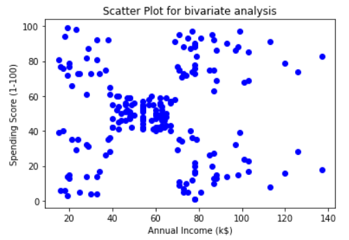

3. Зөвхөн жилийн орлого, зарлагын онооны багануудыг ашиглах тул эдгээр баганы утгуудыг авч, өгөгдлөө бэлдэнэ үү.
4. Кластерийн тоог 1-11 хүртэл авч, "elbow" аргыг ашиглан кластерийн оновчтой тоог тодорхойл. Кластерийн анхны төвийг олохдоо k-means++ аргыг, max_iter дефаулт утгыг тус тус ашиглана.
5. Кластерийн тооны оновчтой утгыг ашиглан K-Means Clustering тооцоолох.
6. Өгөгдлийн багц дахь бичлэг бүр аль кластерийн гишүүн болсныг дараах байдлаар хэвлэж хар.

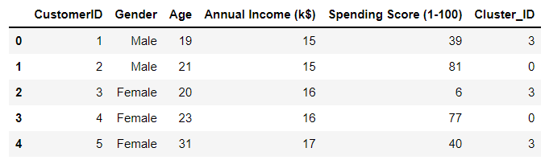

7. (3) даалгаварт бэлдсэн өгөгдлөөр шаталсан кластер үүсгэж, dendrogram байгуулж харна уу. Шаталсан кластерт холболтын төрлийг (linkage type) 'ward' гэж авна уу.
8. (3) даалгаварт бэлдсэн өгөгдлөөр нягтад суурилсан кластер үүсгэ. eps = 10, min_samples = 8